# US Car Accidents

Revealjs Presentation

Group 3: Anthony Fitch, Adib Mazloom, Annabelle Petherbridge, Julia Bautista, & William Jackson

GBA 5910, Cal Poly Pomona

2025-05-01

# **RO2: HOW DOES WEATHER CONDITIONS INFLUENCE** **ACCIDENT FREQUENCY AND SEVERITY?**

## Re-Categorize Weather Conditions

```
[1] "Snow / Sleet / Ice"        "Clear / Fair"
[3] "Cloudy / Overcast"         "Rain / Drizzle"
[5] "Unknown"                   "Fog / Haze / Mist"
[7] "Thunderstorms / Lightning" "Other / Rare"
```

## Conditions and Severity

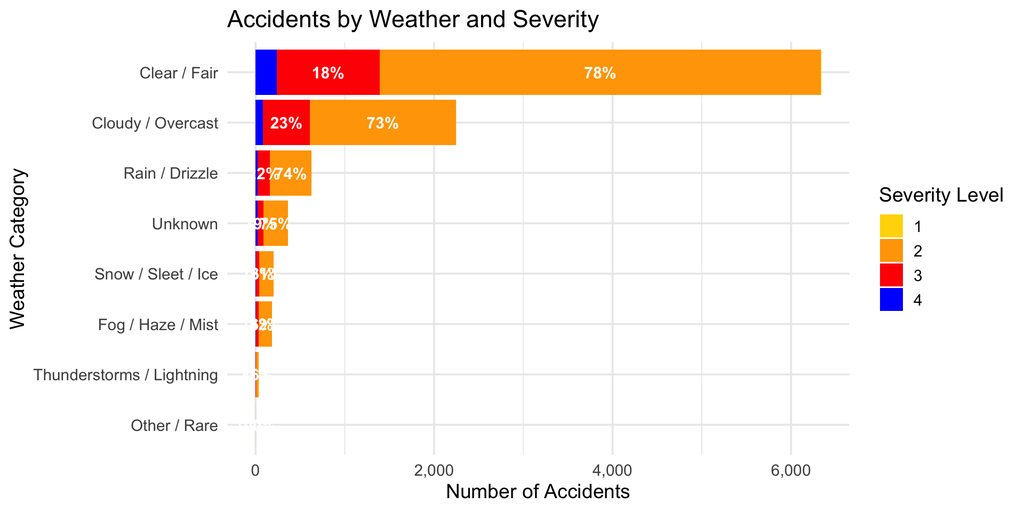

- **Most accidents under all weather conditions are classified as Severity Level 2 (orange)**, indicating moderate severity is the most common outcome regardless of weather type.
- **Severe accidents (Levels 3 and 4) occur more frequently during Clear / Fair conditions** than in adverse weather, likely due to higher traffic volumes or driver overconfidence.

## Re-Group Weather Categories

```r
Data_Set_4_grouped <- Data_Set_4 |>
  mutate(Weather_Group = case_when(
    grepl("Rain|Drizzle", Weather_Condition, ignore.case = TRUE) ~ "Rain",
    grepl("Snow|Sleet|Ice", Weather_Condition, ignore.case = TRUE) ~ "Snow/Ice",
    grepl("Fog|Mist|Haze", Weather_Condition, ignore.case = TRUE) ~ "Fog",
    grepl("Clear|Fair", Weather_Condition, ignore.case = TRUE) ~ "Clear",
    grepl("Cloud|Overcast", Weather_Condition, ignore.case = TRUE) ~ "Cloudy",
    TRUE ~ "Other"
  ))
```

## Accident Counts by Weather Group

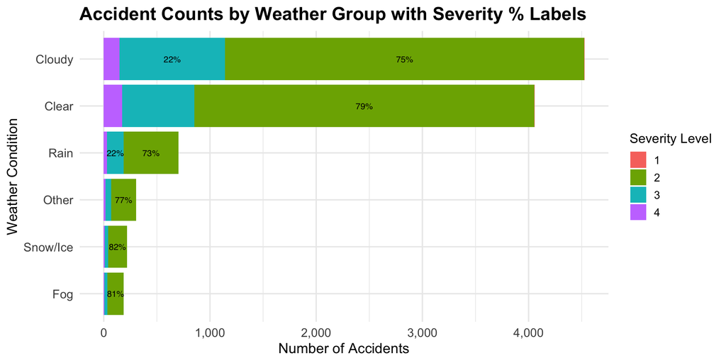

## Chi-Square Test

```
    Chi-squared test for given probabilities

data:  weather_group_counts$n
X-squared = 12565, df = 5, p-value < 2.2e-16
```

- This Chi-Square test was conducted on a **random sample of 10,000 rows** from the full dataset.
- The **p-value is extremely small** (p < 2.2e-16), suggesting that the result is **statistically significant**.
- We **reject the null hypothesis**, which assumes accident counts are evenly distributed across weather groups.
- This implies that **accident frequency significantly varies by weather group**—some weather conditions are associated with more accidents.
- Since the test was based on a **sample**, results may vary slightly across samples, but the **strong significance suggests a real relationship** if the sample is representative of the population.

## Standardized Residuals

```r
chisq_test_result$stdres
```

```
[1]  64.11254  76.72396 -39.64996 -36.51052 -25.85789 -38.81814
```

- Standardized residuals were calculated from a **random 10,000-row sample** of the full dataset.
- **Cloudy and Clear** weather categories had **much more accidents than expected**.
- **Rain, Fog, Snow/Ice, and Other** had **fewer accidents than expected** based on the sample.
- All residuals are **well beyond ±2**, which suggests the differences are **highly statistically significant**.
- These insights are valid **for the sample**, and likely generalize if the sample is representative of the full dataset.

## Logistic Regression: Probability of Severe Accident

```
Call:
glm(formula = Severe_Accident ~ Weather_Group, family = "binomial",
    data = Data_Set_4_grouped)

Coefficients:
                      Estimate Std. Error z value Pr(>|z|)
(Intercept)           -1.32308    0.03853 -34.339  < 2e-16 ***
Weather_GroupCloudy    0.23798    0.05153   4.619 3.87e-06 ***
Weather_GroupFog      -0.15852    0.19118  -0.829 0.407006
Weather_GroupOther     0.08913    0.14212   0.627 0.530549
Weather_GroupRain      0.31536    0.09352   3.372 0.000746 ***
Weather_GroupSnow/Ice -0.18099    0.17900  -1.011 0.311943
---
Signif. codes:  0 '***' 0.001 '**' 0.01 '*' 0.05 '.' 0.1 ' ' 1

(Dispersion parameter for binomial family taken to be 1)

    Null deviance: 10853  on 9999  degrees of freedom
Residual deviance: 10821  on 9994  degrees of freedom
AIC: 10833

Number of Fisher Scoring iterations: 4
```

#### Why Use Logistic Regression?

Logistic regression is used to model **binary outcomes**—in this case, whether an accident is **severe (1)** or **not severe (0)**.

- It estimates the **probability** of a severe accident under different **weather conditions**.
- The model compares each weather type to a **baseline (Clear)** to determine which ones **significantly affect risk**.

# Key Takeaways

**Weather significantly influences accidents** — frequency and severity vary across conditions (*p* < 0.001) in the sample analysis.

**Clear and Cloudy weather account for the most accidents**, likely due to higher traffic volume and exposure.

**Severity Level 2 (moderate)** is the most common outcome across all weather types.

**Cloudy and Rainy conditions increase the odds of severe accidents**, as shown in the logistic regression model.